# Bureau of Transportation Statistics Airline On-Time Performance Data Exploration - Second Half

## Introduction

This is the second half of the exploration notebook for the project. I will be starting with the fully wrangled dataset that was the output from the previous notebook.

```python
# import all packages and set plots to be embedded inline
import numpy as np
import pandas as pd
import matplotlib.pyplot as plt
import seaborn as sns
from IPython.display import display

import matplotlib.patches as mpatches
from matplotlib import rcParams

from matplotlib.ticker import FuncFormatter

%matplotlib inline
```

I will now load the wrangled `flights` dataset that I saved previously.

```python
flights = pd.read_csv("../input/part-i-exploration-ipynb/flights_master.csv", parse_dates = [0, 1, 2, 3])
```

```python
# Removing limit on number of viewable columns
pd.set_option("display.max_columns", None)
```

```python
# Viewing dataframe, dataframe description, and summary statistics
print("\033[1mFlight Data Summary: \033[0m")
display(flights)
print("\n")
flights.info(show_counts = True)
print("\n\033[1mFlight Data Descriptive Statistics:\033[0m")
display(flights.describe(include = "all", datetime_is_numeric=True))
```

```
Flight Data Summary:
```

|  | ActualDepTime | SchedDepTime | ActualArrTime | SchedArrTime | UniqueCarrier | FlightNum | TailNum | ActualElapsedTime | CRSElapsedTime | AirTime | ArrDelay | DepDelay | Origin | Dest | Distance | TaxiIn | TaxiOut | Cancelled | CancellationCode | Diverted | CarrierDelay | WeatherDelay | NASDelay | SecurityDelay | LateAircraftDelay | OverallDelay | FlightRoute |
| --- | --- | --- | --- | --- | --- | --- | --- | --- | --- | --- | --- | --- | --- | --- | --- | --- | --- | --- | --- | --- | --- | --- | --- | --- | --- | --- | --- |
| 0 | 2006-01-11 07:43:00 | 2006-01-11 07:45:00 | 2006-01-11 10:24:00 | 2006-01-11 10:18:00 | US | 343 | N657AW | 281.0 | 273.0 | 223.0 | 6.0 | -2.0 | ATL | PHX | 1587 | 45 | 13 | 0 | NaN | 0 | 0 | 0 | 0 | 0 | 0 | 8.0 | ATL-PHX |
| 1 | 2006-01-11 10:53:00 | 2006-01-11 10:53:00 | 2006-01-11 13:13:00 | 2006-01-11 13:18:00 | US | 613 | N834AW | 260.0 | 265.0 | 214.0 | -5.0 | 0.0 | ATL | PHX | 1587 | 27 | 19 | 0 | NaN | 0 | 0 | 0 | 0 | 0 | 0 | -5.0 | ATL-PHX |
| 2 | 2006-01-11 19:15:00 | 2006-01-11 19:15:00 | 2006-01-11 21:10:00 | 2006-01-11 21:33:00 | US | 617 | N605AW | 235.0 | 258.0 | 220.0 | -23.0 | 0.0 | ATL | PHX | 1587 | 4 | 11 | 0 | NaN | 0 | 0 | 0 | 0 | 0 | 0 | -23.0 | ATL-PHX |
| 3 | 2006-01-11 17:53:00 | 2006-01-11 17:55:00 | 2006-01-11 19:25:00 | 2006-01-11 19:33:00 | US | 300 | N312AW | 152.0 | 158.0 | 126.0 | -8.0 | -2.0 | AUS | PHX | 872 | 16 | 10 | 0 | NaN | 0 | 0 | 0 | 0 | 0 | 0 | -6.0 | AUS-PHX |
| 4 | 2006-01-11 08:24:00 | 2006-01-11 08:32:00 | 2006-01-11 10:15:00 | 2006-01-11 10:15:00 | US | 765 | N309AW | 171.0 | 163.0 | 132.0 | 0.0 | -8.0 | AUS | PHX | 872 | 27 | 12 | 0 | NaN | 0 | 0 | 0 | 0 | 0 | 0 | 8.0 | AUS-PHX |
| ... | ... | ... | ... | ... | ... | ... | ... | ... | ... | ... | ... | ... | ... | ... | ... | ... | ... | ... | ... | ... | ... | ... | ... | ... | ... | ... | ... |
| 7138585 | 2006-12-29 12:46:00 | 2006-12-29 12:49:00 | 2006-12-29 14:52:00 | 2006-12-29 14:59:00 | DL | 1675 | N905DE | 126.0 | 130.0 | 108.0 | -7.0 | -3.0 | ATL | EWR | 745 | 6 | 12 | 0 | NaN | 0 | 0 | 0 | 0 | 0 | 0 | -4.0 | ATL-EWR |
| 7138586 | 2006-12-29 12:25:00 | 2006-12-29 11:55:00 | 2006-12-29 20:33:00 | 2006-12-29 19:31:00 | DL | 1676 | N651DL | 308.0 | 276.0 | 261.0 | 62.0 | 30.0 | SEA | ATL | 2182 | 12 | 35 | 0 | NaN | 0 | 30 | 0 | 32 | 0 | 0 | 32.0 | SEA-ATL |
| 7138587 | 2006-12-29 21:18:00 | 2006-12-29 21:15:00 | 2006-12-29 22:54:00 | 2006-12-29 22:41:00 | DL | 1676 | N143DA | 96.0 | 86.0 | 60.0 | 13.0 | 3.0 | ATL | MCO | 403 | 9 | 27 | 0 | NaN | 0 | 0 | 0 | 0 | 0 | 0 | 10.0 | ATL-MCO |
| 7138588 | 2006-12-29 21:22:00 | 2006-12-29 21:27:00 | 2006-12-29 22:09:00 | 2006-12-29 22:23:00 | DL | 1677 | N904DA | 107.0 | 116.0 | 81.0 | -14.0 | -5.0 | SLC | SJC | 585 | 5 | 21 | 0 | NaN | 0 | 0 | 0 | 0 | 0 | 0 | -9.0 | SLC-SJC |
| 7138589 | 2006-12-29 20:42:00 | 2006-12-29 20:45:00 | 2006-12-29 22:13:00 | 2006-12-29 22:35:00 | DL | 1678 | N914DN | 211.0 | 230.0 | 191.0 | -22.0 | -3.0 | CVG | SLC | 1449 | 5 | 15 | 0 | NaN | 0 | 0 | 0 | 0 | 0 | 0 | -19.0 | CVG-SLC |

7138590 rows × 27 columns

```
<class 'pandas.core.frame.DataFrame'>
RangeIndex: 7138590 entries, 0 to 7138589
Data columns (total 27 columns):
 #   Column             Non-Null Count    Dtype
---  ------             --------------    -----
 0   ActualDepTime      7016660 non-null  datetime64[ns]
 1   SchedDepTime       7138590 non-null  datetime64[ns]
 2   ActualArrTime      7000475 non-null  datetime64[ns]
 3   SchedArrTime       7138590 non-null  datetime64[ns]
 4   UniqueCarrier      7138590 non-null  object
 5   FlightNum          7138590 non-null  int64
 6   TailNum            7138590 non-null  object
 7   ActualElapsedTime  7000475 non-null  float64
 8   CRSElapsedTime     7138590 non-null  float64
 9   AirTime            7000475 non-null  float64
```

[output cut: 21 more lines]

|  | ActualDepTime | SchedDepTime | ActualArrTime | SchedArrTime | UniqueCarrier | FlightNum | TailNum | ActualElapsedTime | CRSElapsedTime | AirTime | ArrDelay | DepDelay | Origin | Dest | Distance | TaxiIn | TaxiOut | Cancelled | CancellationCode | Diverted | CarrierDelay | WeatherDelay | NASDelay | SecurityDelay | LateAircraftDelay | OverallDelay | FlightRoute |
| --- | --- | --- | --- | --- | --- | --- | --- | --- | --- | --- | --- | --- | --- | --- | --- | --- | --- | --- | --- | --- | --- | --- | --- | --- | --- | --- | --- |
| count | 7016660 | 7138590 | 7000475 | 7138590 | 7138590 | 7.138590e+06 | 7138590 | 7.000475e+06 | 7.138590e+06 | 7.000475e+06 | 7.000475e+06 | 7.016660e+06 | 7138590 | 7138590 | 7.138590e+06 | 7.138590e+06 | 7.138590e+06 | 7.138590e+06 | 121930 | 7.138590e+06 | 7.138590e+06 | 7.138590e+06 | 7.138590e+06 | 7.138590e+06 | 7.138590e+06 | 7.000475e+06 | 7138590 |
| unique | NaN | NaN | NaN | NaN | 20 | NaN | 5081 | NaN | NaN | NaN | NaN | NaN | 289 | 296 | NaN | NaN | NaN | NaN | 4 | NaN | NaN | NaN | NaN | NaN | NaN | NaN | 4896 |
| top | NaN | NaN | NaN | NaN | WN | NaN | 0 | NaN | NaN | NaN | NaN | NaN | ATL | ATL | NaN | NaN | NaN | NaN | A | NaN | NaN | NaN | NaN | NaN | NaN | NaN | SAN-LAX |
| freq | NaN | NaN | NaN | NaN | 1099321 | NaN | 72704 | NaN | NaN | NaN | NaN | NaN | 405024 | 404614 | NaN | NaN | NaN | NaN | 55655 | NaN | NaN | NaN | NaN | NaN | NaN | NaN | 14594 |
| mean | 2006-07-03 10:40:42.496671616 | 2006-07-03 16:34:52.787179776 | 2006-07-03 12:46:39.532242816 | 2006-07-03 18:41:43.513584768 | NaN | 2.185732e+03 | NaN | 1.260566e+02 | 1.271929e+02 | 1.035230e+02 | 8.640427e+00 | 1.006358e+01 | NaN | NaN | 7.280638e+02 | 6.405017e+00 | 1.574271e+01 | 1.708040e-02 | NaN | 2.267254e-03 | 3.382614e+00 | 6.627391e-01 | 3.580045e+00 | 3.090540e-02 | 4.511570e+00 | -1.388477e+00 | NaN |
| min | 2006-01-01 00:01:00 | 2005-12-31 18:00:00 | 2006-01-01 00:56:00 | 2005-12-31 19:40:00 | NaN | 1.000000e+00 | NaN | 5.000000e+00 | -9.700000e+01 | 0.000000e+00 | -5.920000e+02 | -1.123000e+03 | NaN | NaN | 1.100000e+01 | 0.000000e+00 | 0.000000e+00 | 0.000000e+00 | NaN | 0.000000e+00 | 0.000000e+00 | 0.000000e+00 | 0.000000e+00 | 0.000000e+00 | 0.000000e+00 | -1.320000e+02 | NaN |
| 25% | 2006-04-04 14:10:00 | 2006-04-04 14:30:00 | 2006-04-04 16:14:00 | 2006-04-04 16:35:00 | NaN | 5.840000e+02 | NaN | 7.500000e+01 | 7.600000e+01 | 5.400000e+01 | -9.000000e+00 | -4.000000e+00 | NaN | NaN | 3.160000e+02 | 4.000000e+00 | 1.000000e+01 | 0.000000e+00 | NaN | 0.000000e+00 | 0.000000e+00 | 0.000000e+00 | 0.000000e+00 | 0.000000e+00 | 0.000000e+00 | -9.000000e+00 | NaN |
| 50% | 2006-07-04 08:41:00 | 2006-07-04 15:25:00 | 2006-07-04 10:29:00 | 2006-07-04 17:30:00 | NaN | 1.493000e+03 | NaN | 1.070000e+02 | 1.090000e+02 | 8.500000e+01 | -1.000000e+00 | 0.000000e+00 | NaN | NaN | 5.740000e+02 | 5.000000e+00 | 1.300000e+01 | 0.000000e+00 | NaN | 0.000000e+00 | 0.000000e+00 | 0.000000e+00 | 0.000000e+00 | 0.000000e+00 | 0.000000e+00 | -3.000000e+00 | NaN |
| 75% | 2006-10-01 13:27:00 | 2006-10-01 20:05:00 | 2006-10-01 15:57:00 | 2006-10-01 22:05:00 | NaN | 3.434000e+03 | NaN | 1.560000e+02 | 1.570000e+02 | 1.320000e+02 | 1.300000e+01 | 9.000000e+00 | NaN | NaN | 9.560000e+02 | 8.000000e+00 | 1.800000e+01 | 0.000000e+00 | NaN | 0.000000e+00 | 0.000000e+00 | 0.000000e+00 | 0.000000e+00 | 0.000000e+00 | 0.000000e+00 | 4.000000e+00 | NaN |
| max | 2007-01-01 00:00:00 | 2006-12-31 23:59:00 | 2007-01-01 10:04:00 | 2007-01-01 13:10:00 | NaN | 9.619000e+03 | NaN | 9.000000e+02 | 1.031000e+03 | 1.059000e+03 | 1.779000e+03 | 1.752000e+03 | NaN | NaN | 4.962000e+03 | 9.560000e+02 | 6.020000e+02 | 1.000000e+00 | NaN | 1.000000e+00 | 1.666000e+03 | 1.163000e+03 | 1.374000e+03 | 3.540000e+02 | 1.366000e+03 | 5.980000e+02 | NaN |
| std | NaN | NaN | NaN | NaN | NaN | 1.989229e+03 | NaN | 7.119734e+01 | 7.032629e+01 | 6.950362e+01 | 3.645321e+01 | 3.325261e+01 | NaN | NaN | 5.746217e+02 | 4.959762e+00 | 1.126816e+01 | 1.295711e-01 | NaN | 4.756169e-02 | 1.869779e+01 | 8.333399e+00 | 1.557741e+01 | 1.273829e+00 | 1.983964e+01 | 1.381017e+01 | NaN |

```python
flights.to_csv("flights_exploratory.csv", index = False)
```

### What is the structure of your dataset?

The dataset has 7138590 flights and 27 features:

- ActualDepTime, the actual departure time of a flight,
- SchedDepTime, the scheduled departure time of a flight,
- ActualArrTime, the actual arrival time of a flight,
- SchedArrTime, the scheduled arrival time of a flight,
- UniqueCarrier, the unique carrier code,
- FlightNum, the flight number,
- TailNum, the tail number of the plane,
- ActualElapsedTime, the actual elapsed time, in minutes,
- CRSElapsedTime, the scheduled elasped time, in minutes,
- AirTime, the air time for the flight, in minutes
- ArrDelay, the arrival delay, in minutes,
- DepDelay, the departure delay, in minutes,
- Origin, the origin airport IATA code,
- Dest, the destination airport IATA code,
- Distance, the distance between origin and destination airport, in miles,
- TaxiIn, taxi in time, in minutes,
- TaxiOut, taxi out time, in minutes,
- Cancelled, whether flight was cancelled, 1 = yes, 0 = no,
- CancellationCode, reason for cancellation (A = carrier, B = weather, C = NAS, D = security)
- Diverted, whether flight was diverted or not, 1 = yes, 0 = no,
- CarrierDelay, in minutes,
- WeatherDelay, in minutes,
- NASDelay, in minutes,
- SecurityDelay, in minutes,
- LateAircraftDelay, in minutes,
- OverallDelay, overall delay, in minutes
- FlightRoute, unique route identifier.

### What is/are the main feature(s) of interest in your dataset?

I am interested in finding out the factors that contribute to flight delays, and, conversely early flights, in this dataset.

### What features in the dataset do you think will help support your investigation into your feature(s) of interest?

I will be looking at the distance between airports, `Dist`, the scheduled duration of a flight, represented by `CRSElapsedTime`, and the `FlightRoute`. I will also be looking at the `OverallDelay`, as well as the contrast between arrival delays and departure delays, `ArrDelay` and `DepDelay`.

Before commencing my analysis, I am going to add new categorical variables to the data. `is_arr_delayed` to represent whether the flight landed late or not, `is_dep_delayed` for whether the flight departed late or not, `is_overall_delayed` for whether the flight was overall longer or shorter than was scheduled, `is_daytime_arr` and `is_daytime_dep`, for whether the flight is scheduled to arrive/depart during the day or not.

```python
# Arrival is delayed if ArrDelay is positive
flights.loc[flights["ArrDelay"] <= 0, "is_arr_delayed"] = 0
flights.loc[flights["ArrDelay"] > 0, "is_arr_delayed"] = 1

flights[["ArrDelay", "is_arr_delayed"]].sample(5)
```

|  | ArrDelay | is_arr_delayed |
| --- | --- | --- |
| 3658424 | 36.0 | 1.0 |
| 5338807 | -9.0 | 0.0 |
| 768032 | 45.0 | 1.0 |
| 472336 | -9.0 | 0.0 |
| 6367603 | 9.0 | 1.0 |

```python
# Departure is delayed if DepDelay is positive
flights.loc[flights["DepDelay"] <= 0, "is_dep_delayed"] = 0
flights.loc[flights["DepDelay"] > 0, "is_dep_delayed"] = 1

flights[["DepDelay", "is_dep_delayed"]].sample(5)
```

|  | DepDelay | is_dep_delayed |
| --- | --- | --- |
| 719149 | -1.0 | 0.0 |
| 5530371 | 7.0 | 1.0 |
| 1606993 | 33.0 | 1.0 |
| 1523907 | -5.0 | 0.0 |
| 3270348 | 20.0 | 1.0 |

```python
# Flight is overall delayed if OverallDelay is positive
flights.loc[flights["OverallDelay"] <= 0, "is_overall_delayed"] = 0
flights.loc[flights["OverallDelay"] > 0, "is_overall_delayed"] = 1

flights[["OverallDelay", "is_overall_delayed"]].sample(5)
```

|  | OverallDelay | is_overall_delayed |
| --- | --- | --- |
| 4830199 | -5.0 | 0.0 |
| 2682982 | -9.0 | 0.0 |
| 3329549 | -3.0 | 0.0 |
| 1483297 | 3.0 | 1.0 |
| 2656115 | 4.0 | 1.0 |

```python
# Arrival is in daytime if the scheduled hour of arrival is between 6 AM inclusive and 6 PM exclusive
flights.loc[(flights["SchedArrTime"].dt.hour).isin(range(6,18)), "is_daytime_arr"] = 1
flights.loc[(flights["SchedArrTime"].dt.hour).isin([18, 19, 20, 21, 22, 23, 0, 1, 2, 3, 4, 5]), "is_daytime_arr"] = 0

flights[["SchedArrTime", "is_daytime_arr"]].sample(5)
```

|  | SchedArrTime | is_daytime_arr |
| --- | --- | --- |
| 1951272 | 2006-04-21 14:45:00 | 1.0 |
| 4292558 | 2006-08-30 13:19:00 | 1.0 |
| 4950035 | 2006-09-27 09:15:00 | 1.0 |
| 3492454 | 2006-06-22 15:24:00 | 1.0 |
| 3261298 | 2006-06-02 13:09:00 | 1.0 |

```python
# Departure is in daytime if scheduled hour of departure is between 6 AM inclusive and 6 PM exclusive
flights.loc[(flights["SchedDepTime"].dt.hour).isin(range(6,18)), "is_daytime_dep"] = 1
flights.loc[(flights["SchedDepTime"].dt.hour).isin([18, 19, 20, 21, 22, 23, 0, 1, 2, 3, 4, 5]), "is_daytime_dep"] = 0

flights[["SchedDepTime", "is_daytime_dep"]].sample(5)
```

|  | SchedDepTime | is_daytime_dep |
| --- | --- | --- |
| 832574 | 2006-02-24 12:31:00 | 1.0 |
| 4926844 | 2006-09-12 20:50:00 | 0.0 |
| 6211846 | 2006-11-22 07:30:00 | 1.0 |
| 944055 | 2006-02-08 21:25:00 | 0.0 |
| 422036 | 2006-01-20 19:01:00 | 0.0 |

I now move on to the analysis. I wil begin with univariate exploration.

## Univariate Exploration

In this section, I will be exploring several variables, one at a time.

I will first look at the distribution of `DepDelay`.

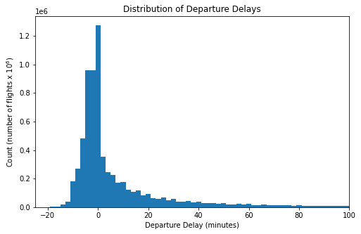

```python
# Creating bins for histogram
bins = np.arange(flights["DepDelay"].min()-2, flights["DepDelay"].max()+2, 2)

plt.figure(figsize=(8, 5));
plt.hist(flights["DepDelay"], bins = bins);
plt.xlabel("Departure Delay (minutes)");
plt.ylabel("Count (number of flights x $10^6$)");
plt.title("Distribution of Departure Delays");
# Setting x-axis limits
plt.xlim((-25,100));
plt.show();
```

The distribution shows a right skew. I will transfom the data using a log scale to see if that yields a lognormal distribution.

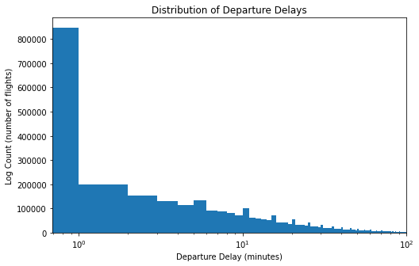

```python
# Creating bins for histogram
bins = np.arange(flights["DepDelay"].min()-1, flights["DepDelay"].max()+1, 1)

plt.figure(figsize=(8, 5));
plt.hist(flights["DepDelay"], bins = bins);
# Setting log scale
plt.xscale("log");
plt.xlabel("Departure Delay (minutes)");
plt.ylabel("Log Count (number of flights)");
plt.title("Distribution of Departure Delays");
# Setting x-axis limits
plt.xlim(right = 100);
plt.show();
```

The histogram still shows a long tail, therefore this variable does not have a lognormal distribution.

I now look at the distribution of the values in the `ArrDelay` column.

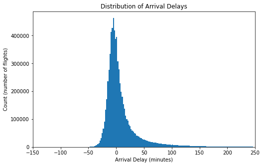

```python
# Creating bins for histogram
bins = np.arange(flights["ArrDelay"].min()-2, flights["ArrDelay"].max()+2, 2)

plt.figure(figsize=(8, 5));
plt.hist(flights["ArrDelay"], bins = bins);
plt.xlabel("Arrival Delay (minutes)");
plt.ylabel("Count (number of flights)");
plt.title("Distribution of Arrival Delays");
# Setting x-axis limits
plt.xlim((-150,250));
plt.show();
```

The distribution has a heavy right skew. I will use a log scale to find out whether it is lognormal.

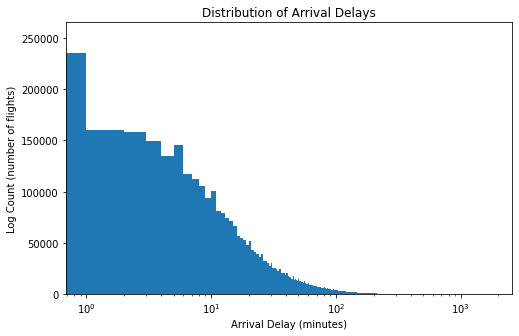

```python
# Creating bins for histogram
bins = np.arange(flights["ArrDelay"].min()-1, flights["ArrDelay"].max()+1, 1)

plt.figure(figsize=(8, 5));
plt.hist(flights["ArrDelay"], bins = bins);
# Setting log scale
plt.xscale("log");
plt.xlabel("Arrival Delay (minutes)");
plt.ylabel("Log Count (number of flights)");
plt.title("Distribution of Arrival Delays");
plt.show();
```

The histogram continues to show a heavy right skew. Therefore I can conclude that the distribution is neither normal nor lognormal.

I will now look at the distribution of the `OverallDelay` column.

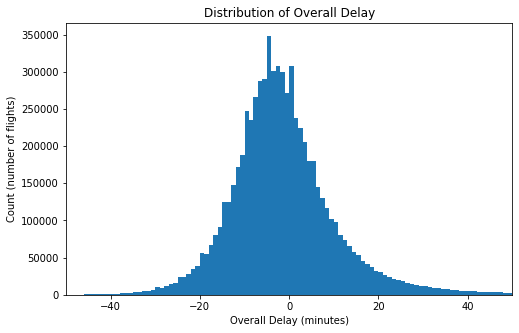

```python
# Creating bins for histogram
bins = np.arange(flights["OverallDelay"].min()-1, flights["OverallDelay"].max()+1, 1)

plt.figure(figsize=(8, 5));
plt.hist(flights["OverallDelay"], bins = bins);
plt.xlabel("Overall Delay (minutes)");
plt.ylabel("Count (number of flights)");
plt.title("Distribution of Overall Delay");
# Setting x-axis limits
plt.xlim((-50,50));
plt.show();
```

The histogram shows that the overall delay has a normal distribution.

I will now look at the distribution of the distance between airports.

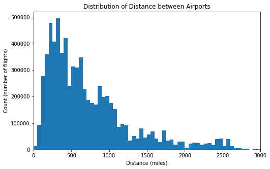

```python
# Creating bins for histogram
bins = np.arange(0, flights["Distance"].max()+50, 50)

plt.figure(figsize=(8, 5));
plt.hist(flights["Distance"], bins = bins);
plt.xlabel("Distance (miles)");
plt.ylabel("Count (number of flights)")
plt.title("Distribution of Distance between Airports")
# Setting x-axis limits
plt.xlim((0,3000));
plt.show();
```

The distribution shows a long tail to the right. I will look at whether the distribution changes when on a log scale.

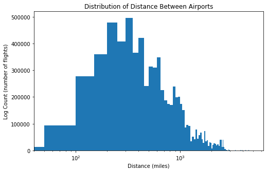

```python
# Creating bins for histogram
bins = np.arange(0, flights["Distance"].max()+50, 50)

plt.figure(figsize=(8, 5));
plt.hist(flights["Distance"], bins = bins);
# Setting log scale
plt.xscale("log");
plt.xlabel("Distance (miles)");
plt.ylabel("Log Count (number of flights)");
plt.title("Distribution of Distance Between Airports");
plt.show();
```

The distribution shifts significantly to the right, and is almost symmetrical. This indicates the distribution of the distance is close to lognormal.

I now look at the distribution of the actual flight duration, `ActualElapsedTime`.

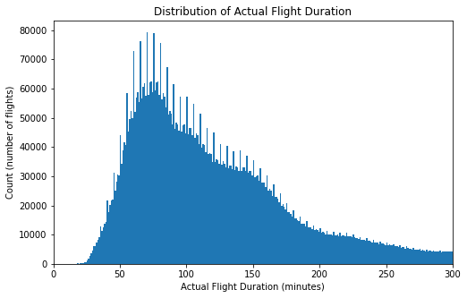

```python
# Creating bins for histogram
bins = np.arange(0, flights["ActualElapsedTime"].max()+1, 1)

plt.figure(figsize=(8, 5));
plt.hist(flights["ActualElapsedTime"], bins = bins);
plt.xlabel("Actual Flight Duration (minutes)");
plt.ylabel("Count (number of flights)");
plt.title("Distribution of Actual Flight Duration");
# Setting x-axis limits
plt.xlim((0,300));
plt.show();
```

The distribution has a long tail to the right. I will try using a log scale to see if the distribution is possibly lognormal.

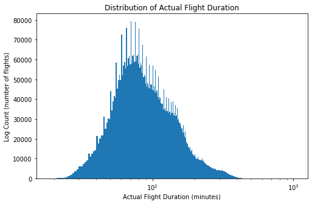

```python
# Creating bins for histogram
bins = np.arange(0, flights["ActualElapsedTime"].max()+1, 1)

plt.figure(figsize=(8, 5));
plt.hist(flights["ActualElapsedTime"], bins = bins);
# Setting log scale
plt.xscale("log")
plt.xlabel("Actual Flight Duration (minutes)");
plt.ylabel("Log Count (number of flights)");
plt.title("Distribution of Actual Flight Duration");
# Setting x-axis limit
plt.xlim(left = 15);
plt.show();
```

The distribution is more symmetrical, although the slope of the left side is smoother than the slope on the right side. The distribution seems to be lognormal here.

I now look at the distribution of the scheduled flight duration.

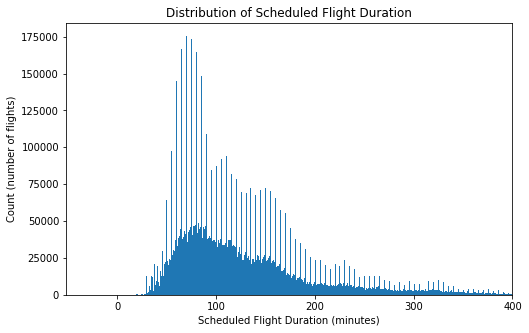

```python
# Creating bins for histogram
bins = np.arange(0, flights["CRSElapsedTime"].max()+1, 1)

plt.figure(figsize=(8, 5));
plt.hist(flights["CRSElapsedTime"], bins = bins);
plt.xlabel("Scheduled Flight Duration (minutes)");
plt.ylabel("Count (number of flights)");
plt.title("Distribution of Scheduled Flight Duration");
# Setting x-axis limits
plt.xlim(right = 400);
plt.show();
```

The distribution has a long tail to the right. I will try using a log scale to see if the distribution is possibly lognormal.

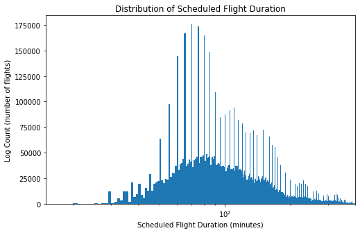

```python
# Creating bins for histogram
bins = np.arange(0, flights["CRSElapsedTime"].max()+1, 1)

plt.figure(figsize=(8, 5));
plt.hist(flights["CRSElapsedTime"], bins = bins);
# Setting log scale
plt.xscale("log")
plt.xlabel("Scheduled Flight Duration (minutes)");
plt.ylabel("Log Count (number of flights)");
plt.title("Distribution of Scheduled Flight Duration");
# Setting x-axis limit
plt.xlim(left = 15, right = 400);
plt.show();
```

The distribution is now more symmetrical, although the smoothness has not improved for different bin sizes. However, like the actual flight duration, this variable also seems to have an approximately lognormal distribution.

I now look at the fraction of actual departures for each hour of day.

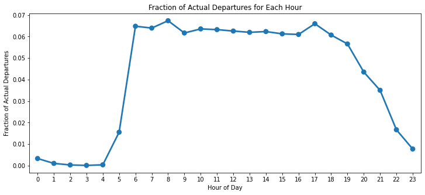

```python
plt.figure(figsize=(12, 5));
# Extracting hour from actual departure times and expressing as decimal
hourly_departures = flights["ActualDepTime"].dt.hour.value_counts().sort_index()/len(flights[flights["ActualDepTime"].notnull()])
sns.pointplot(x = hourly_departures.index, y = hourly_departures.values);
# Changing x-axis labels from float to int
plt.gca().xaxis.set_major_formatter(FuncFormatter(lambda x, _: int(x)));
plt.title("Fraction of Actual Departures for Each Hour");
plt.xlabel("Hour of Day");
plt.ylabel("Fraction of Actual Departures");
```

Most flights depart between 6 AM and 6 PM, before slowly tapering off, with each hour in that range averaging 6% to 7% of all departures. The fewest departures are between midnight and 4 AM, averaging less than 1% of total departures for each hour.

I will now look at the hourly trends of actual arrivals.

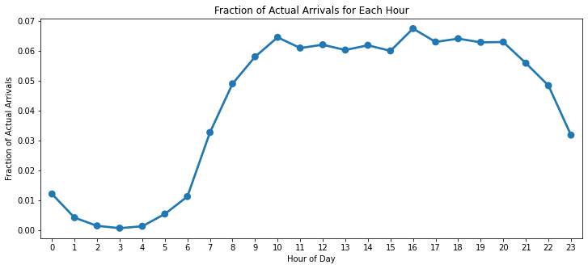

```python
plt.figure(figsize=(12, 5));
# Extracting hour from actual arrival times and expressing as decimal
hourly_arrivals = flights["ActualArrTime"].dt.hour.value_counts().sort_index()/len(flights[flights["ActualArrTime"].notnull()])
sns.pointplot(x = hourly_arrivals.index, y = hourly_arrivals.values);
# Changing x-axis labels from float to int
plt.gca().xaxis.set_major_formatter(FuncFormatter(lambda x, _: int(x)));
plt.title("Fraction of Actual Arrivals for Each Hour");
plt.xlabel("Hour of Day");
plt.ylabel("Fraction of Actual Arrivals");
```

The majority of flights land between 10 AM and 8 PM, with the highest peak at 4 PM. There is a sharp drop in arrivals from 11 PM to midnight, and then a smoother decrease until the lowest point at 3 AM. From 4 AM, the number of arrivals starts to gently pick up again.

I will now look at the hourly patterns for scheduled departures.

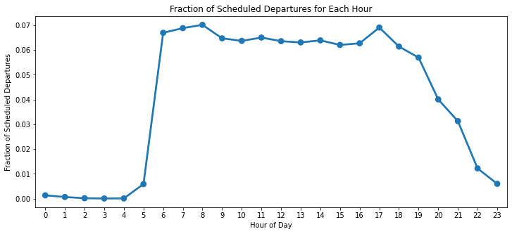

```python
plt.figure(figsize=(12, 5));
# Extracting hour from scheduled departure times and expressing as decimal
hourly_departures_sched = flights["SchedDepTime"].dt.hour.value_counts().sort_index()/len(flights[flights["SchedDepTime"].notnull()]);
sns.pointplot(x = hourly_departures_sched.index, y = hourly_departures_sched.values);
# Changing x-axis labels from float to int
plt.gca().xaxis.set_major_formatter(FuncFormatter(lambda x, _: int(x)));
plt.title("Fraction of Scheduled Departures for Each Hour");
plt.xlabel("Hour of Day");
plt.ylabel("Fraction of Scheduled Departures");
```

From midnight to 4 AM, the number of scheduled departures is almost 0. There is sharp increase from less than 1% of scheduled departures at 5 AM, to about 7% at 6AM. The trend remains between 6% and 7% until 5PM when it begins to slowly deckine. The highest peaks are at 8 AM and 5PM.

I will now look at the hourly trends for scheduled arrivals.

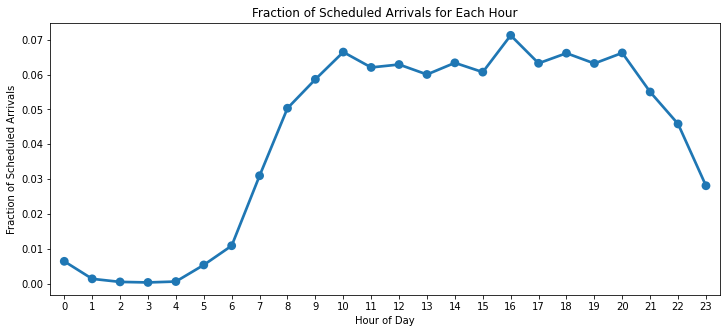

```python
plt.figure(figsize=(12, 5));
# Extracting hour from scheduled arrival times and expressing as decimal
hourly_arrivals_sched = flights["SchedArrTime"].dt.hour.value_counts().sort_index()/len(flights[flights["SchedArrTime"].notnull()]);
sns.pointplot(x = hourly_arrivals_sched.index, y = hourly_arrivals_sched.values);
# Changing x-axis labels from float to int
plt.gca().xaxis.set_major_formatter(FuncFormatter(lambda x, _: int(x)));
plt.title("Fraction of Scheduled Arrivals for Each Hour");
plt.xlabel("Hour of Day");
plt.ylabel("Fraction of Scheduled Arrivals");
```

This trend has a more jagged profile than the other 3 that I've looked at it. Most arrivals are scheduled for between 10 AM and 8 PM, with the most arrivals scheduled for around 4PM. There are almost no flights scheduled to land betweem 1 AM and 4 AM, and a gentle upward trend begins at 5 AM.

I will now look at the 15 most flown flight routes.

```python
# The colour palette I will be using for my visualizations
my_palette = [sns.color_palette()[7], sns.color_palette()[9]]
```

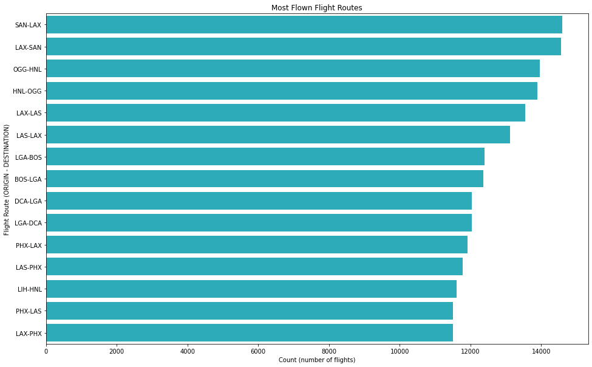

```python
# Extracting 15 highest entries
flight_routes_plot = flights["FlightRoute"].value_counts()[:15]

plt.figure(figsize = (16, 10))
sns.barplot(x=flight_routes_plot, y=flight_routes_plot.index, color=my_palette[1]);
plt.title("Most Flown Flight Routes");
plt.xlabel("Count (number of flights)");
plt.ylabel("Flight Route (ORIGIN - DESTINATION)");
```

It would seem most routes are flown equally frequently in either direction. Several airports show up in multiple different routes, like LAX, PHX, and LAS. I would expect that each of these airports features near the top of the list of most frequently appearing airports in the dataset.

To xplore this further, I will now look at the 15 airports with the highest number of flights departing from them, and then the 15 airports with the most landings.

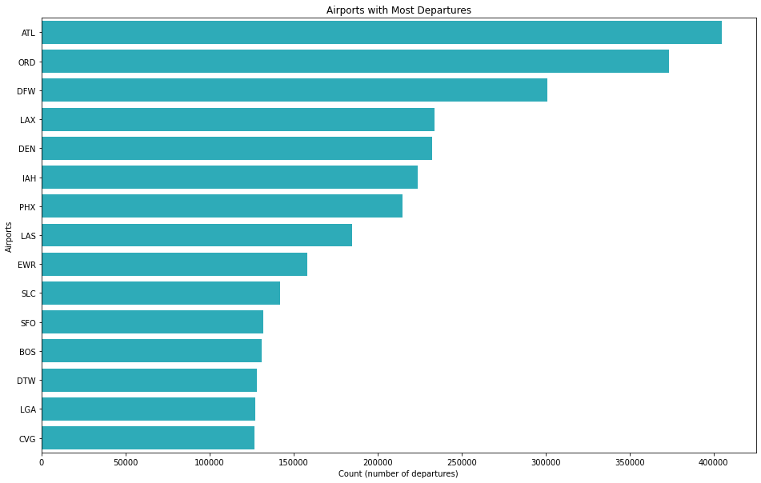

```python
# Extracting 15 highest values
origins_plot = flights["Origin"].value_counts()[:15]

plt.figure(figsize = (16, 10));
sns.barplot(x=origins_plot, y=origins_plot.index, color=my_palette[1]);
plt.title("Airports with Most Departures");
plt.xlabel("Count (number of departures)");
plt.ylabel("Airports");
```

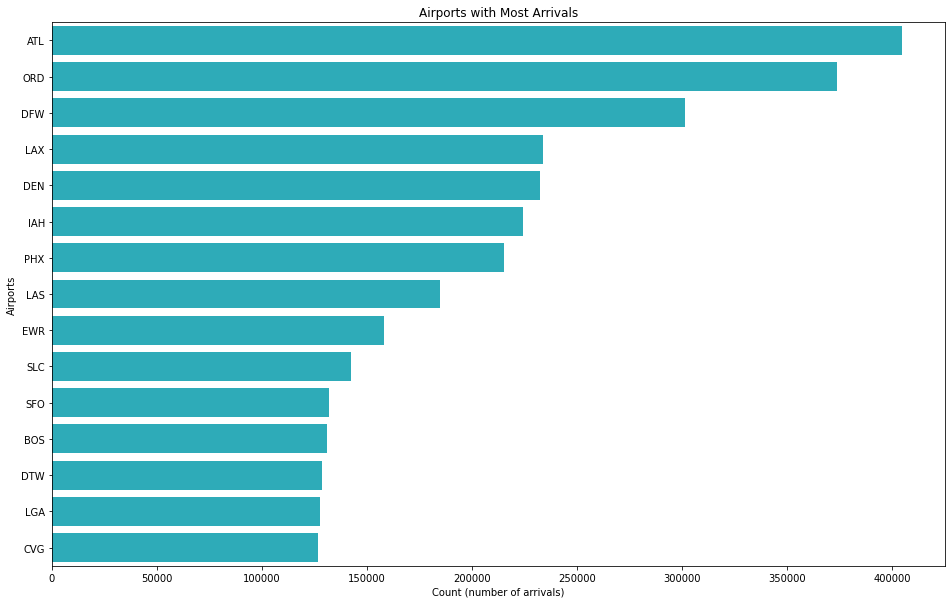

```python
# Extracting 15 highest values
dest_plot = flights["Dest"].value_counts()[:15]

plt.figure(figsize = (16, 10))
sns.barplot(x=dest_plot, y=dest_plot.index, color=my_palette[1]);
plt.title("Airports with Most Arrivals");
plt.xlabel("Count (number of arrivals)");
plt.ylabel("Airports");
```

Interestingly, the 3 top busiest airports do not feature at all in the most flown routes. However, as suspected, LAX, LAS, and PHX make the list as some of the busiest airports. Additionaly, the 15 busiest destinations are also the 15 busiest origin airports, in the same order. This reveals a new insight that was not readily visible before, that airports are flown to almost exactly as much as they are departed from. This would also explain the trend in the flight routes plot, where many routes have almost the same value in each direction.

I will now move on to looking at the fraction of flights that arrive and depart during the day versus during the night.

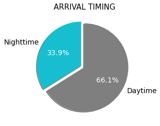

```python
# Fraction of flights that land during daytime and nighttime
_, _, autotexts = plt.pie(flights['is_daytime_arr'].value_counts(), labels = ['Daytime', 'Nighttime'],
        colors=my_palette, startangle = 90, counterclock = False, shadow = True, textprops = {"size": 14},
        explode = (0, 0.08), radius = 1.0, autopct = '%1.1f%%')
# Set pie chart text colour
for ins in autotexts:
    ins.set_color('white')
plt.title("ARRIVAL TIMING", size = 15);
plt.show();
```

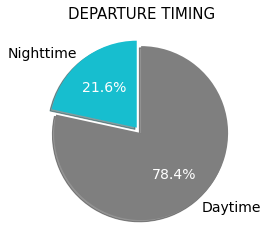

```python
# Fraction of flights that take off during daytime and nighttime
_, _, autotexts = plt.pie(flights['is_daytime_dep'].value_counts(), labels = ['Daytime', 'Nighttime'],
        colors=my_palette, startangle = 90, counterclock = False, shadow = True, textprops = {"size": 14},
        explode = (0, 0.08), radius = 1.0, autopct = '%1.1f%%')
# # Set pie chart text colour
for ins in autotexts:
    ins.set_color('white')
plt.title("DEPARTURE TIMING", size=15)
plt.show()
```

Unsurprisingly, given the hourly trend line plots earlier, the majority of flights depart and land during the day. A larger percentage of departures than arrivals are during the day.

I now look at the fraction of flight departures and arrivals that are on time versus delayed.

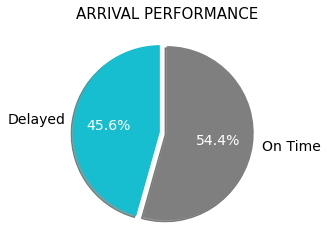

```python
# Fraction of flights that arrive on time and do not
_, _, autotexts = plt.pie(flights['is_arr_delayed'].value_counts(), labels = ['On Time', 'Delayed'],
        colors=my_palette, startangle = 90, counterclock = False, shadow = True, textprops = {"size": 14},
        explode = (0, 0.08), radius = 1.0, autopct = '%1.1f%%')
# Set pie chart text colour
for ins in autotexts:
    ins.set_color('white');
plt.title('ARRIVAL PERFORMANCE', size = 15);
plt.show();
```

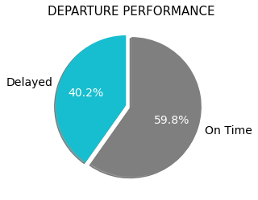

```python
# Fraction of flights that take depart on time and do not
_, _, autotexts = plt.pie(flights['is_dep_delayed'].value_counts(), labels = ['On Time', 'Delayed'],
        colors=my_palette, startangle = 90, counterclock = False, shadow = True, textprops = {"size": 14},
        explode = (0, 0.08), radius = 1.0, autopct = '%1.1f%%')
# Set pie chart text colour
for ins in autotexts:
    ins.set_color('white')
plt.title('DEPARTURE PERFORMANCE', size = 15)
plt.show()
```

There are less delayed flights than on time flights for both arrivals and departures. Departures have slightly more flights on time than arrivals.

Finally, I will look at overall flight performance by exploring the percentage of flights that take longer than the scheduled duration.

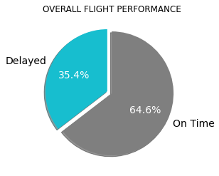

```python
# Fraction of flights that take longer than scheduled and do not
_, _, autotexts = plt.pie(flights['is_overall_delayed'].value_counts(), labels = ['On Time', 'Delayed'],
        colors=my_palette, startangle = 90, counterclock = False, shadow = True, textprops = {"size": 14},
        explode = (0, 0.08), radius = 1.0, autopct = '%1.1f%%')
# Set pie chart text colour
for ins in autotexts:
    ins.set_color('white')
plt.title('OVERALL FLIGHT PERFORMANCE')
plt.show()
```

More flights overall took shorter than their scheduled duration.

### Discuss the distribution(s) of your variable(s) of interest. Were there any unusual points? Did you need to perform any transformations?

`DepDelay` has a heavy right skew. I applied the log transformation, and the result maintained the right skew. Thus, this variable does not have either a normal or lognormal distribution.

Similarly to the above, `ArrDelay` has a right skew, with the log transformed distribution also having a right skew. The conclusion was this variable does not follow a normal distribution.

`OverallDelay` showed a normal distribution, without need for any transformations.

`Distance` has a right skew when linearly scaled. With a log scale, the distribution was almost symmetrical. The conclusion was that the variable follows a lognormal distribution.

`ActualElapsedTime` is right skewed. When a log scale is applied, the distribution is more symmetrical, although with a smoother slope on the left than on the right. The conclusion was this distribution is approximately lognormal. `CRSElapsedTime` showed similar distribution after similar transformation.

### Of the features you investigated, were there any unusual distributions? Did you perform any operations on the data to tidy, adjust, or change the form of the data? If so, why did you do this?

Much of the tidying necessary was already completed during the wrangling phase, and thus there was no further work in that regard. However, some outliers still remained for some of the variables, and limits had to be applied on the x-axes of many of the histograms, for readability and intrepretability of the plots.

## Bivariate Exploration

In this section, I'll investigate the relationships between pairs of variables.

I will start by looking at the scheduled departure times by hour of day, segmented by whether the flights were on time or delayed.

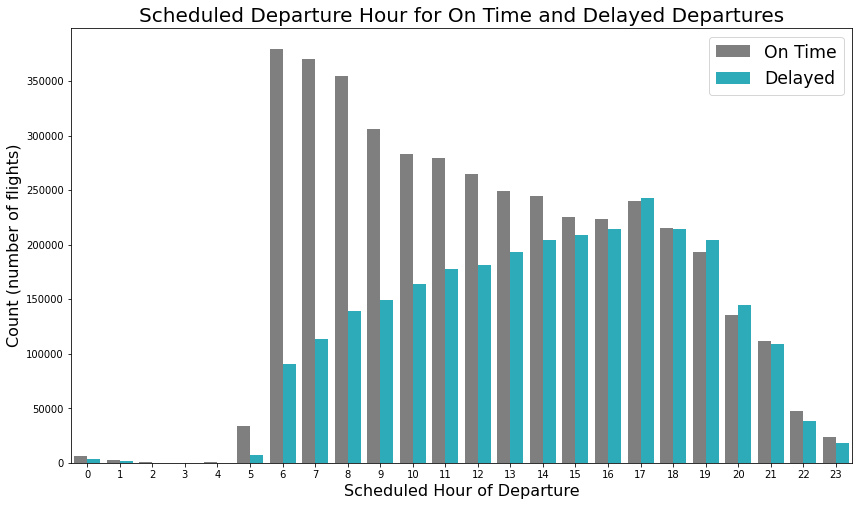

```python
# Scheduled flight departures per hour for delayed and on time flights
plt.figure(figsize = (14, 8))
sns.countplot(x=flights['SchedDepTime'].dt.hour, hue=flights['is_dep_delayed'], palette=my_palette)
# Changing x-axis labels from float to int
plt.gca().xaxis.set_major_formatter(FuncFormatter(lambda x, _: int(x)));
plt.title('Scheduled Departure Hour for On Time and Delayed Departures', size=20)
plt.xlabel("Scheduled Hour of Departure", fontsize=16)
plt.ylabel("Count (number of flights)", fontsize=16)
plt.legend(labels = ["On Time", "Delayed"], fontsize = "xx-large")
plt.show();
```

There aren't many departures either way scheduled for between midnight and 5 AM. For flights scheduled to take off from 5 AM onwards, there are more on time departures than delayed departures. On time departures peak for departures scheduled at 6 AM, and slowly decrease until they are temporarily surpassed by delayed departures between 5 PM and 8 PM.

I will now look at the same relationship but with arrivals instead.

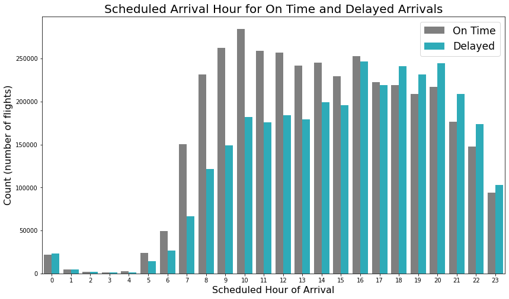

```python
# Scheduled flight arrivals per hour for delayed and on time flights
plt.figure(figsize = (14, 8));
sns.countplot(x=flights['SchedArrTime'].dt.hour, hue=flights['is_arr_delayed'], palette=my_palette);
# Changing x-axis labels from float to int
plt.gca().xaxis.set_major_formatter(FuncFormatter(lambda x, _: int(x)));
plt.title('Scheduled Arrival Hour for On Time and Delayed Arrivals', size=20);
plt.xlabel("Scheduled Hour of Arrival", fontsize=16);
plt.ylabel("Count (number of flights)", fontsize=16);
plt.legend(labels = ["On Time", "Delayed"], fontsize = "xx-large");
plt.show();
```

There are more on time arrivals for arrivals scheduled between 4 AM and 6 PM. Delayed arrivals peak for flights scheduled to arrive at 4 PM and at 8 PM, and on time arrivals peak for 10 AM arrivals.

I will now look at patterns in flight duration between overall on time and delayed flights.

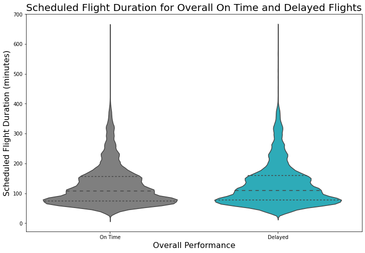

```python
# Scheduled flight duration for delayed and on time flights
# sns.set_style("darkgrid")
plt.figure(figsize = (12, 8))
sns.violinplot(x=flights["is_overall_delayed"], y=flights["CRSElapsedTime"], palette = my_palette, inner='quartile');
plt.xticks([0, 1], ["On Time", "Delayed"]);
plt.title('Scheduled Flight Duration for Overall On Time and Delayed Flights', fontsize=20);
plt.xlabel("Overall Performance", size = 16);
plt.ylabel("Scheduled Flight Duration (minutes)", size = 16);
```

The range of outliers in flight duration is similar for delayed and on time flights. The median flight duration is also the same for both groups. The violins show a similar distribution in scheduled flight duration.

I will now explore flight distances for on time and delayed flights.

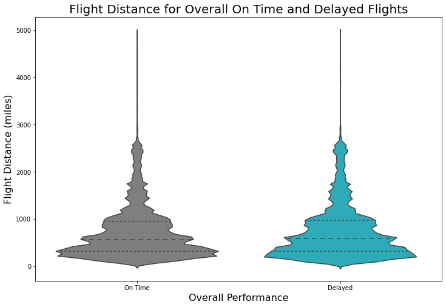

```python
# Flight duration for delayed and on time flights
# sns.set_style("darkgrid")
plt.figure(figsize = (12, 8))
sns.violinplot(x=flights["is_overall_delayed"], y=flights["Distance"], palette = my_palette, inner='quartile');
plt.xticks([0, 1], ["On Time", "Delayed"]);
plt.title('Flight Distance for Overall On Time and Delayed Flights', fontsize=20);
plt.xlabel("Overall Performance", size = 16);
plt.ylabel("Flight Distance (miles)", size = 16);
```

The median distance and range of outliers are very similar for both on time and delayed flights, with the median only very slightly higher for delayed flights. The distribution of distance is the same for both groups.

### Talk about some of the relationships you observed in this part of the investigation. How did the feature(s) of interest vary with other features in the dataset?

I observed that flights scheduled to depart in the late afternoon to early evening saw more delayed than on time flights.

Flights scheduled to arrive at 6 PM or later also showed more delayed flights, while flights earlier in the day had more on time flights.

Additionally, flight delays tend to happen to similar extents for both longer flights and shorter flights, in terms of duration.

Expectedly, following from the above, the relationship with flight distance is similar for both groups, since more distant flights are likely to have higher durations. The distribution of distance is almost exactly the same for both gorups.

### Did you observe any interesting relationships between the other features (not the main feature(s) of interest)?

No further relationships were observed.

## Multivariate Exploration

In this section, I will study 3 or more variables at a time for more insights.

I will start by investigating the relationship with flight duration, for delayed and on time flights, grouped by different scheduled times of arrival.

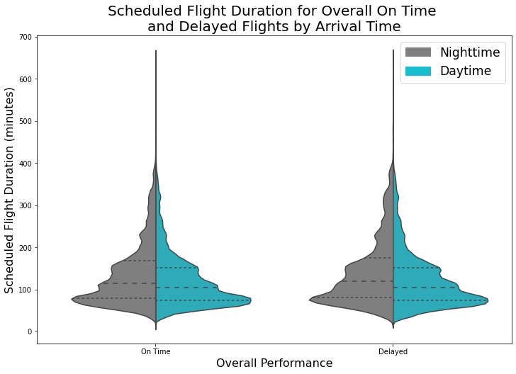

```python
# Scheduled flight duration for delayed and on time flights by scheduled time of arrival
# sns.set_style("darkgrid")
plt.figure(figsize = (12, 8))
sns.violinplot(x=flights["is_overall_delayed"], y=flights["CRSElapsedTime"], hue=flights['is_daytime_arr'],
               palette = my_palette, inner = "quartile", split = True);
plt.xticks([0, 1], ["On Time", "Delayed"]);
plt.title('Scheduled Flight Duration for Overall On Time \nand Delayed Flights by Arrival Time', fontsize=20);
plt.xlabel("Overall Performance", size = 16);
plt.ylabel("Scheduled Flight Duration (minutes)", size = 16);
daytime_handle = mpatches.Patch(color=my_palette[1], label='Daytime')
nighttime_handle = mpatches.Patch(color=my_palette[0], label='Nighttime')
plt.legend(handles = [nighttime_handle, daytime_handle], fontsize = "xx-large");
plt.show();
```

Flights scheduled for nighttime arrival have slightly higher median scheduled flight durations, for both delayed and on time flights.

I will now look at the same but for scheduled departures.

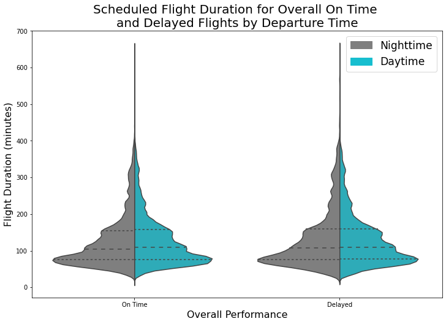

```python
# Scheduled flight duration for delayed and on time flights by time of departure
# sns.set_style("darkgrid")
plt.figure(figsize = (12, 8))
sns.violinplot(x=flights["is_overall_delayed"], y=flights["CRSElapsedTime"], hue=flights['is_daytime_dep'],
               palette = my_palette, inner = "quartile", split = True);
plt.xticks([0, 1], ["On Time", "Delayed"]);
plt.title('Scheduled Flight Duration for Overall On Time \nand Delayed Flights by Departure Time', fontsize=20);
plt.xlabel("Overall Performance", size = 16);
plt.ylabel("Flight Duration (minutes)", size = 16);
daytime_handle = mpatches.Patch(color=my_palette[1], label='Daytime')
nighttime_handle = mpatches.Patch(color=my_palette[0], label='Nighttime')
plt.legend(handles = [nighttime_handle, daytime_handle], fontsize = "xx-large");
plt.show();
```

Flights with departures scheduled for nigthtime have very slightly lower median scheduled durations, but are otherwise very similar to flights scheduled for daytime.

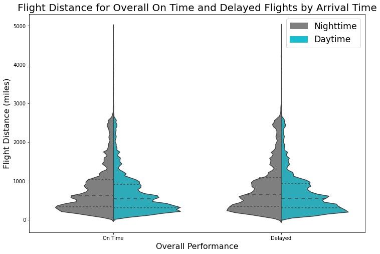

```python
# Flight distance for delayed and on time flights by time of arrival
# sns.set_style("darkgrid")
plt.figure(figsize = (12, 8))
sns.violinplot(x=flights["is_overall_delayed"], y=flights["Distance"], hue=flights['is_daytime_arr'],
               palette = my_palette, inner = "quartile", split = True);
plt.xticks([0, 1], ["On Time", "Delayed"]);
plt.title('Flight Distance for Overall On Time and Delayed Flights by Arrival Time', fontsize=20);
plt.xlabel("Overall Performance", size = 16);
plt.ylabel("Flight Distance (miles)", size = 16);
daytime_handle = mpatches.Patch(color=my_palette[1], label='Daytime')
nighttime_handle = mpatches.Patch(color=my_palette[0], label='Nighttime')
plt.legend(handles = [nighttime_handle, daytime_handle], fontsize = "xx-large");
plt.show();
```

Median flight distance is higher for flights scheduled for nighttime arrival than for daytime arrival. The distributions are similar for both groups, for both on time and delayed flights.

Finally, I look at the same relationship, but with departure times.

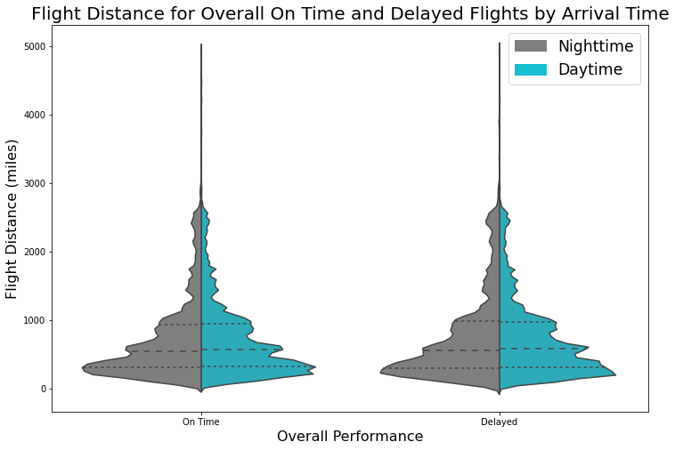

```python
# Flight distance for delayed and on time flights by time of departure
# sns.set_style("darkgrid")
plt.figure(figsize = (12, 8))
sns.violinplot(x=flights["is_overall_delayed"], y=flights["Distance"], hue=flights['is_daytime_dep'],
               palette = my_palette, inner = "quartile", split = True);
plt.xticks([0, 1], ["On Time", "Delayed"]);
plt.title('Flight Distance for Overall On Time and Delayed Flights by Arrival Time', fontsize=20);
plt.xlabel("Overall Performance", size = 16);
plt.ylabel("Flight Distance (miles)", size = 16);
daytime_handle = mpatches.Patch(color=my_palette[1], label='Daytime')
nighttime_handle = mpatches.Patch(color=my_palette[0], label='Nighttime')
plt.legend(handles = [nighttime_handle, daytime_handle], fontsize = "xx-large");
plt.show();
```

As per the pattern in this section, the distributions are similar for both on time performance groups, and for both daytime and nighttime departures. The median flight distance is slightly lower for nighttime scheduled departures.

### Talk about some of the relationships you observed in this part of the investigation. Were there features that strengthened each other in terms of looking at your feature(s) of interest?

Flights scheduled for nighttime arrivals showed higher durations than those scheduled for daytime arrivals.

The relationship was the opposite for scheduled flight durations, which showed shorter flight durations.

Fittingly, both of the above applied to flight distances as well.

### Were there any interesting or surprising interactions between features?

No further observations were made.

## Conclusions

Several helpful conclusions have been drawn from this analysis, and the questions I had were answered sufficiently through the data and appropriate visualizations. Most notably, I expected there to be larger differences in the relationships with distance and duration, between on time flights and delayed flights. However, this has proven not to be the case.

I initially intended to investigate several more relationships, including for cancelled and diverted flights, and for individual planes. However, seeing as I have already managed to acquire several insights from the exploratory analysis, I will save the rest of my directions of inquiry for future work.

I will now move on to presenting the explanatory analysis in a separate notebook.